# Good Plot Bad Plot

Shane Jordan

3/22/2021

## **Introduction**

For this exercise in good and bad plot making, I will use long-term average precipitation data collected by the Western Regional Climate Center for 31 sites across the Mojave Desert and plot it against the elevation of each site. Because precipitation may vary depending on longitude due to monsoonal climate influence from the east, the goal is to make a scatter plot that separates site by longitude (east or west of 116 degrees). Then, use the plot to show the effect of elevation on precipitation, and how this effect is distinguished by longitude. This might show if higher elevations of the east Mojave receive more rainfall than similarly high elevations of the west Mojave.

## **Libraries and Data**

```r
#libraries
library(tidyr)
library(dplyr)
library(car)
library(moments)
library(tidyverse)
library(here)
library(ggplot2)

#Import the data
precip <- read_csv('C:/Users/pfura/Documents/Biol 551L/Jordan/Week_7/Data/precipitation.csv')

#make a factorial linear model
model1<-lm(precip ~ longitude*elev, data=precip)

#prep data to plot
predprecip<-predict(model1) #makes regression lines
graphdata<-cbind(precip, predprecip)
```

## **Good Plot**

Looking at the plot, it appears that precipitation depends upon elevation at all 31 sites, however, the more eastern sites seem to receive more precipitation. There might be evidence of the monsoon influencing the eastern Mojave climate.

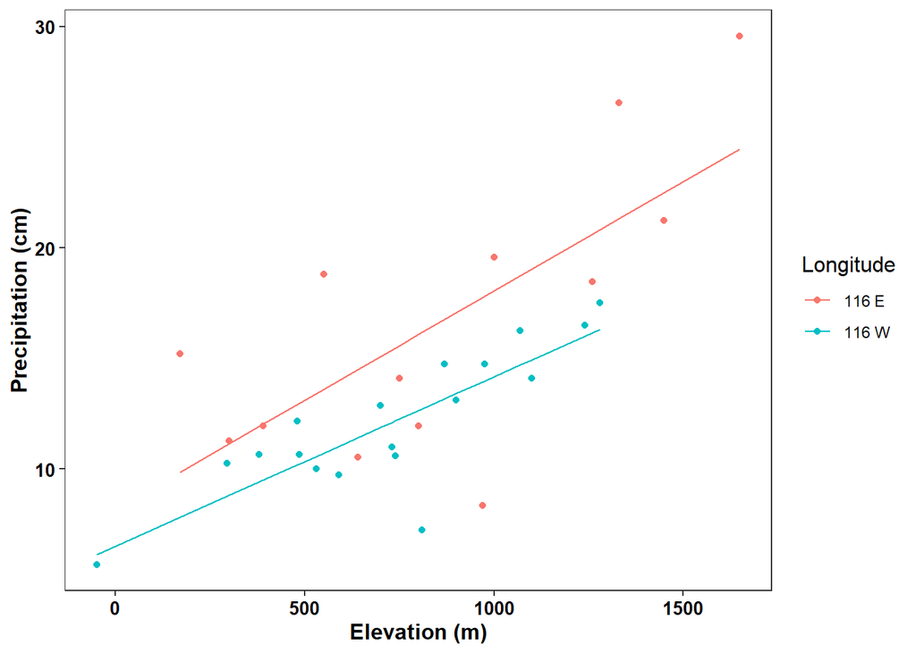

```r
precip %>%
  rename(Longitude=longitude) %>% #first, we need to rename "ï..longitude" as     "Longitude"
  ggplot(aes(elev, precip, color=Longitude)) +
  theme_bw()+
  theme(legend.title=element_text(colour="black", size=12),
        axis.text.x=element_text(face="bold", color="black", size=10),
        axis.text.y=element_text(face="bold", color="black", size=10),
        axis.title.x = element_text(color="black", size=12, face="bold"),
        axis.title.y = element_text(color="black", size=12, face="bold"),
        panel.grid.major=element_blank(), panel.grid.minor=element_blank()) +
  geom_point() + geom_line(aes(y=predprecip)) +
  labs(x="Elevation (m)", y="Precipitation (cm)", fill="longitude")
```